# ggplot2_chapter3

Nade Kang

July 8, 2018

# Solution Manual for ggplot2 Elegant Graphics for Data Analysis by Hadley Wickham

# ggplot2 Chpater 3 Toolbox

## *Exercise 3.2.1*

### Load Packages

```r
knitr::opts_chunk$set(echo = TRUE)
library(tidyverse)
```

*Question 1* What geoms would you use to draw each of the following named plots? 1. Scatterplot: geom_point() 2. Line chart: geom_line() 3. Histogram: geom_histogram() 4. Bar chart: geom_bar() 5. Pie chart: geom_bar() + coord_polar(“y”)

*Question 2* What’s the difference between geom path() and geom polygon()? What’s the difference between geom path() and geom line()?

geom_path() connects the observations in the order in which they appear in the data. geom_line() connects them in order of the variable on the x axis. Polygons are very similar to paths (as drawn by geom_path) except that the start and end points are connected and the inside is coloured by fill. geom_path() connects the observations in the order in which they appear in the data. geom_line() connects them in order of the variable on the x axis.

*Question 3* What low-level geoms are used to draw geom smooth()? What about geom boxplot() and geom violin()?

geom_point(), geom_path(), and geom_area() are used to draw with geom_smooth(). geom_rect(), geom_line(), geom_point() are used for geom_boxplot(). geom_area() and geom_path() are used for geom_violin()

## *Exercises 3.5.5*

*Question 1* Draw a boxplot of hwy for each value of cyl, without turning cyl into a factor. What extra aesthetic do you need to set?

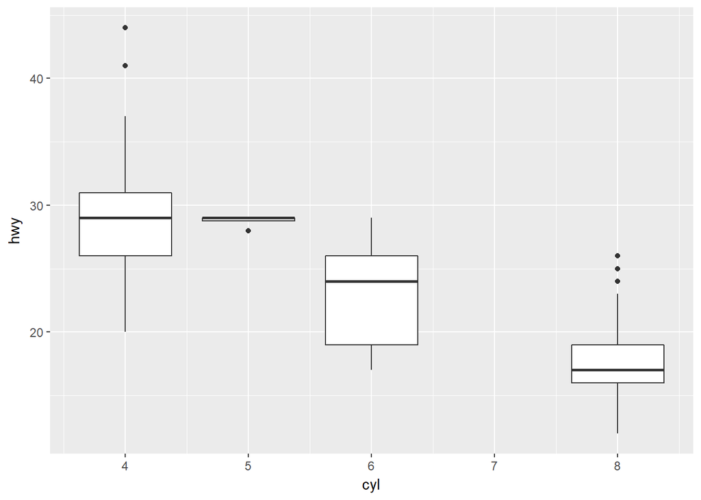

```r
ggplot(mpg, aes(cyl, hwy, group = cyl)) +
  geom_boxplot()
```

You simply add a “group = cyl” argument within the overall aes in ggplot()

*Question 2* Modify the following plot so that you get one boxplot per integer value of displ.

```r
ggplot(mpg, aes(displ, cty)) +
geom_boxplot()
```

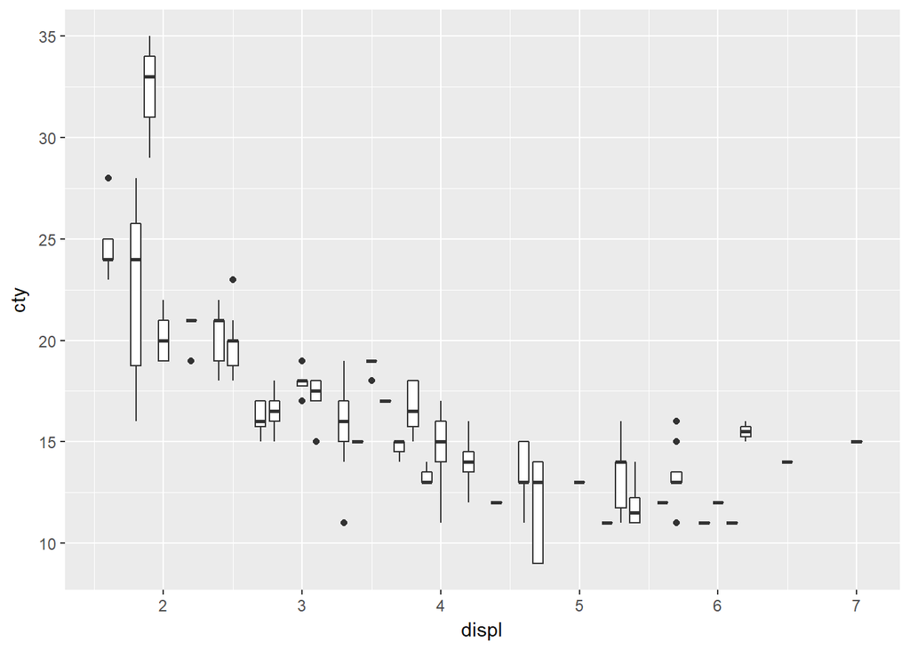

```r
ggplot(mpg, aes(displ, cty)) +
  geom_boxplot(aes(group = displ))
```

*Question 3* When illustrating the difference between mapping continuous and discrete colours to a line, the discrete example needed aes(group = 1). Why?What happens if that is omitted? What’s the difference between aes(group = 1) and aes(group = 2)? Why?

The important thing (for a line graph with a factor on the horizontal axis) is to manually specify the grouping. By default ggplot2 uses the combination of all categorical variables in the plot to group geoms - that doesn’t work for this plot because you get an individual line for each point. Manually specify group = 1 indicates you want a single line connecting all the points.

*Question 4* How many bars are in each of the following plots?

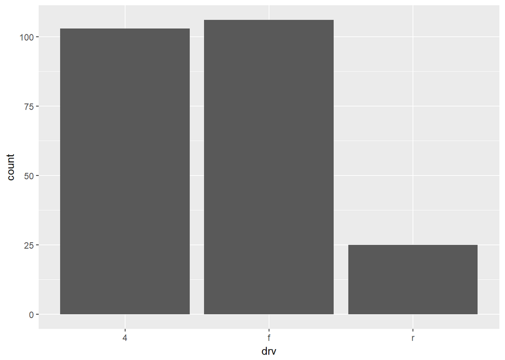

```r
ggplot(mpg, aes(drv)) + geom_bar()
```

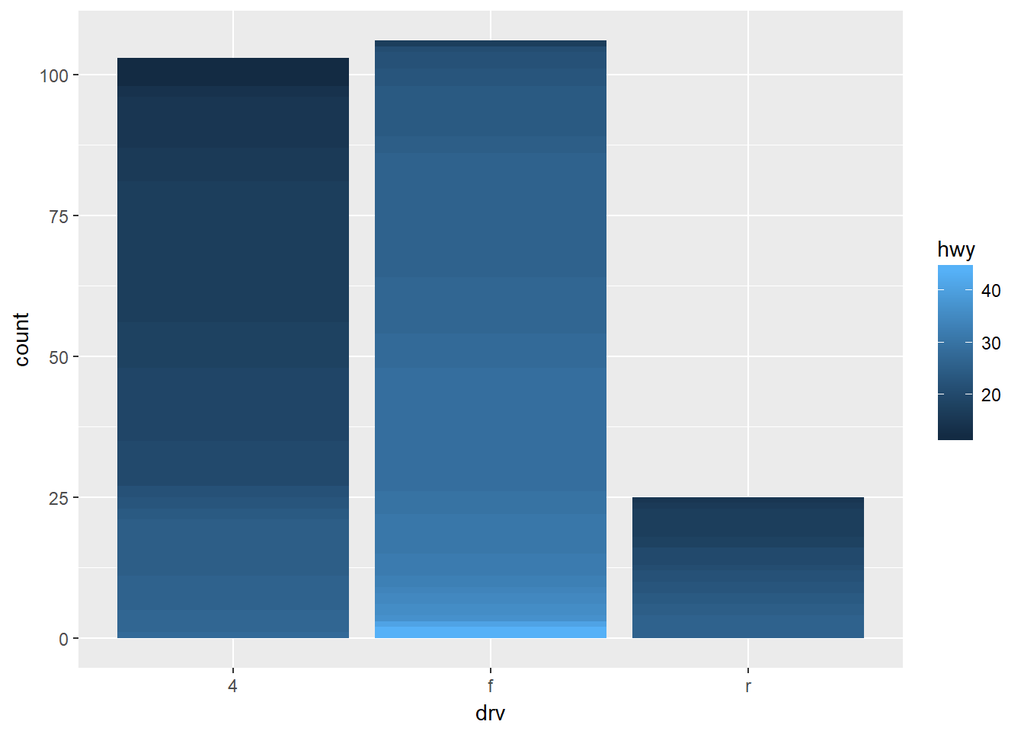

```r
ggplot(mpg, aes(drv, fill = hwy, group = hwy)) + geom_bar()
```

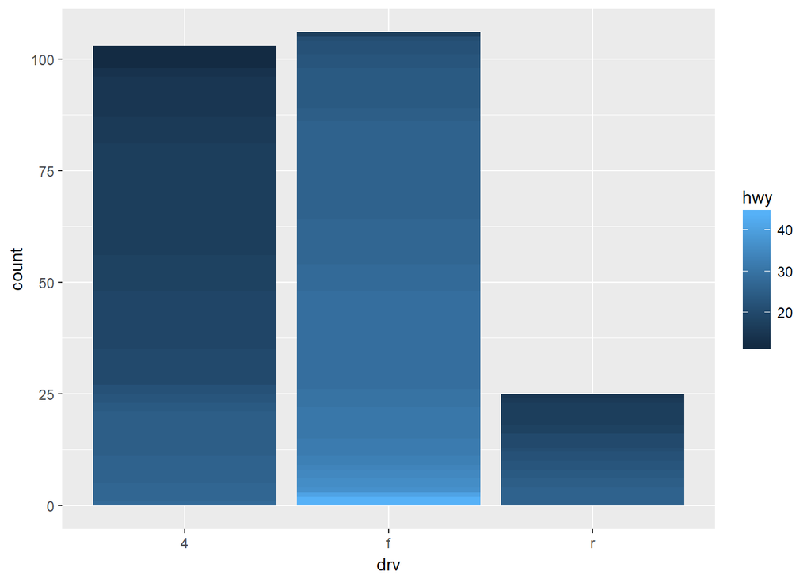

```r
library(dplyr)
mpg2 <- mpg %>% arrange(hwy) %>% mutate(id = seq_along(hwy))
ggplot(mpg2, aes(drv, fill = hwy, group = id)) + geom_bar()
```

All have 3 bars.

*Question 5* Install the babynames package. It contains data about the popularity of babynames in the US. Run the following code and fix the resulting graph. Why does this graph make me unhappy?

```r
install.packages("babynames")
```

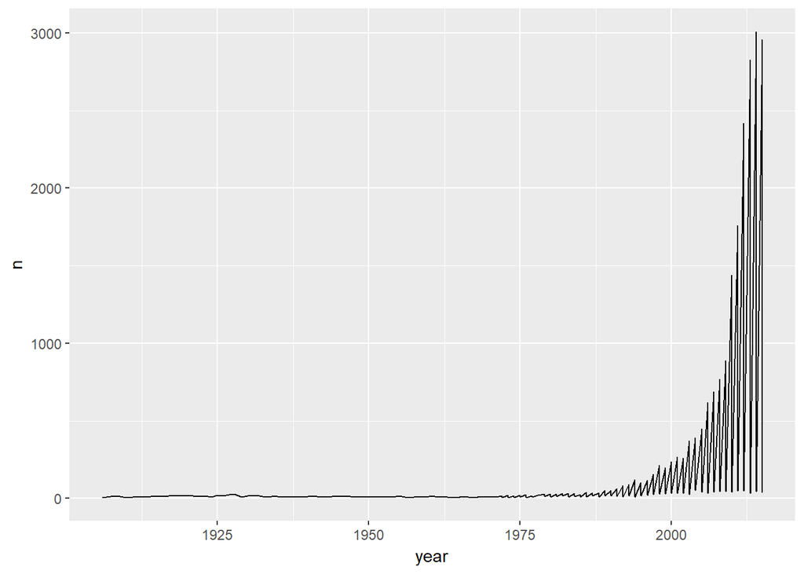

```r
library(babynames)
hadley <- dplyr::filter(babynames, name == "Hadley")
ggplot(hadley, aes(year, n)) +
geom_line()
```

We want to see the growth of the new born babies with name called “Hadley”. This graph doesn’t show the full picture, and the shape of the line is not a good representation of the number of names we want to see. In addition, if you check the data, the count is separated by sex(gender). As a result, this line plot cannot show us the full details of the name Hadley’s number’s variation across the years. Starting in 1960s, there are female babies named as “Hadley”.

```r
hadley
```

```
## # A tibble: 159 x 5
##     year sex   name       n      prop
##    <dbl> <chr> <chr>  <int>     <dbl>
##  1  1906 M     Hadley     6 0.0000416
##  2  1908 M     Hadley    16 0.0000962
##  3  1909 M     Hadley    14 0.0000792
##  4  1910 M     Hadley     5 0.0000240
##  5  1911 M     Hadley     9 0.0000373
##  6  1912 M     Hadley    11 0.0000244
##  7  1913 M     Hadley    10 0.0000186
##  8  1914 M     Hadley    15 0.0000220
##  9  1915 M     Hadley    14 0.0000159
## 10  1916 M     Hadley    14 0.0000152
## # ... with 149 more rows
```

```r
male <- hadley %>%
  filter(sex == "M")
male
```

```
## # A tibble: 107 x 5
##     year sex   name       n      prop
##    <dbl> <chr> <chr>  <int>     <dbl>
##  1  1906 M     Hadley     6 0.0000416
##  2  1908 M     Hadley    16 0.0000962
##  3  1909 M     Hadley    14 0.0000792
##  4  1910 M     Hadley     5 0.0000240
##  5  1911 M     Hadley     9 0.0000373
##  6  1912 M     Hadley    11 0.0000244
##  7  1913 M     Hadley    10 0.0000186
##  8  1914 M     Hadley    15 0.0000220
##  9  1915 M     Hadley    14 0.0000159
## 10  1916 M     Hadley    14 0.0000152
## # ... with 97 more rows
```

```r
female <- hadley %>%
  filter(sex == "F")
female
```

```
## # A tibble: 52 x 5
##     year sex   name       n       prop
##    <dbl> <chr> <chr>  <int>      <dbl>
##  1  1964 F     Hadley     7 0.00000358
##  2  1965 F     Hadley     6 0.00000328
##  3  1966 F     Hadley     8 0.00000456
##  4  1967 F     Hadley     6 0.00000350
##  5  1968 F     Hadley     6 0.00000351
##  6  1969 F     Hadley    10 0.00000567
##  7  1970 F     Hadley    13 0.00000710
##  8  1971 F     Hadley    10 0.00000571
##  9  1972 F     Hadley    19 0.0000118
## 10  1973 F     Hadley    20 0.0000129
## # ... with 42 more rows
```

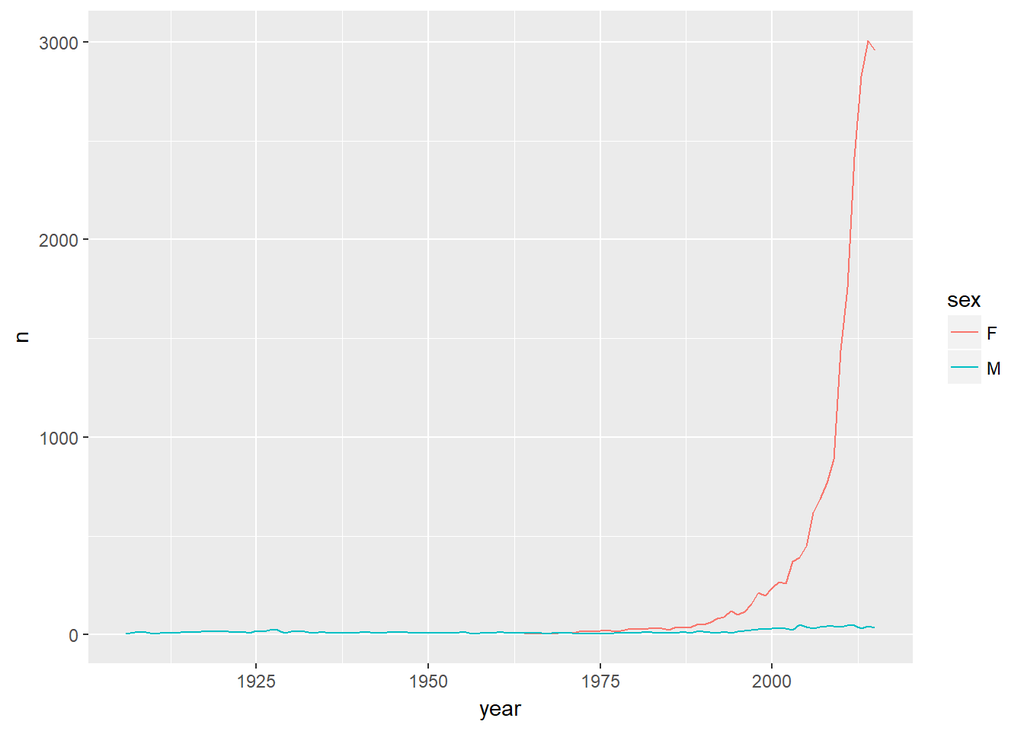

```r
ggplot(hadley) +
  geom_line(aes(year, n, color = sex))
```

## *Exercises 3.11.1*

*Question 1* What binwidth tells you the most interesting story about the distribution of carat?

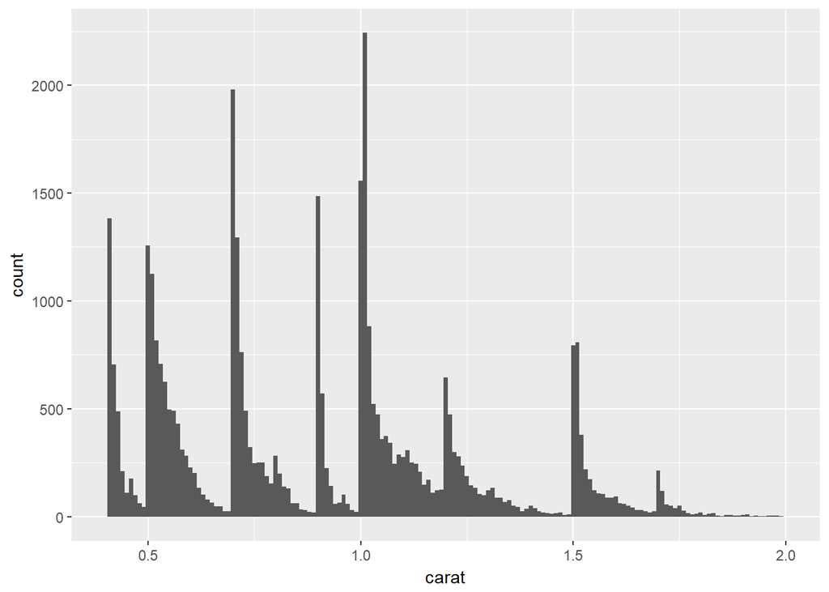

```r
ggplot(diamonds, aes(carat)) +
  geom_histogram(binwidth = 0.01) +
  xlim(0.4, 2)
```

Zooming in using xlim, we can see that a binwidth = 0.01 reveals some interesting pattern in terms of carat and number of diamonds.

*Question 2* Draw a histogram of price. What interesting patterns do you see?

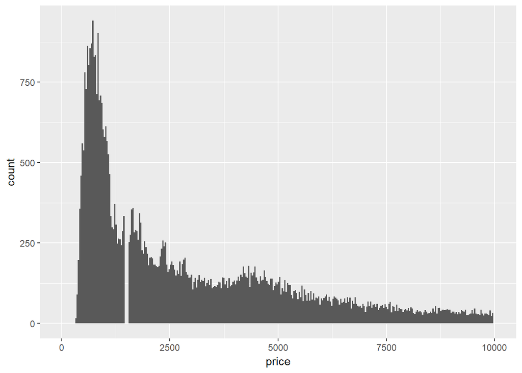

```r
ggplot(diamonds, aes(price)) +
  geom_histogram(binwidth = 30) +
  xlim(0, 10000)
```

Not quite familiar with diamonds, so it’s hard for me to say what kind of pattern there is. But you could try to adjust the binwidth and xlim() to see different patterns.

*Question 3* How does the distribution of price vary with clarity?

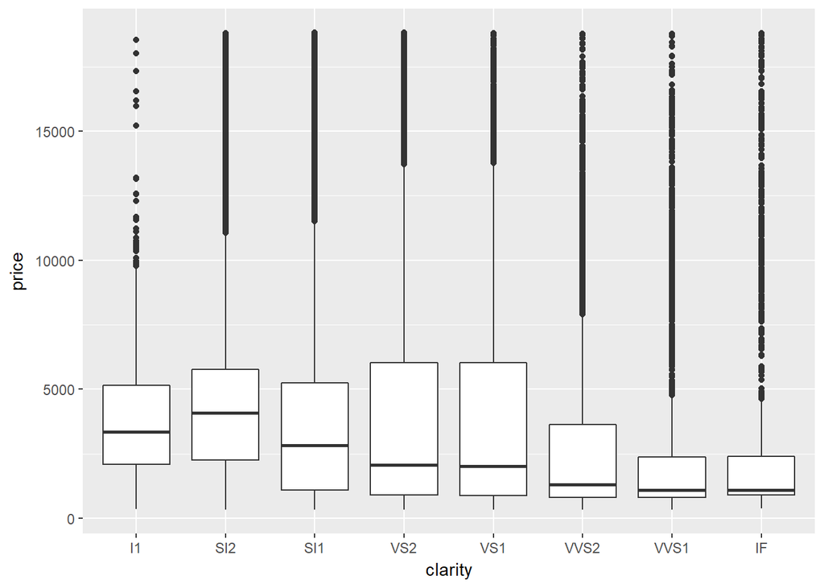

```r
ggplot(diamonds, aes(clarity, price)) +
  geom_boxplot()
```

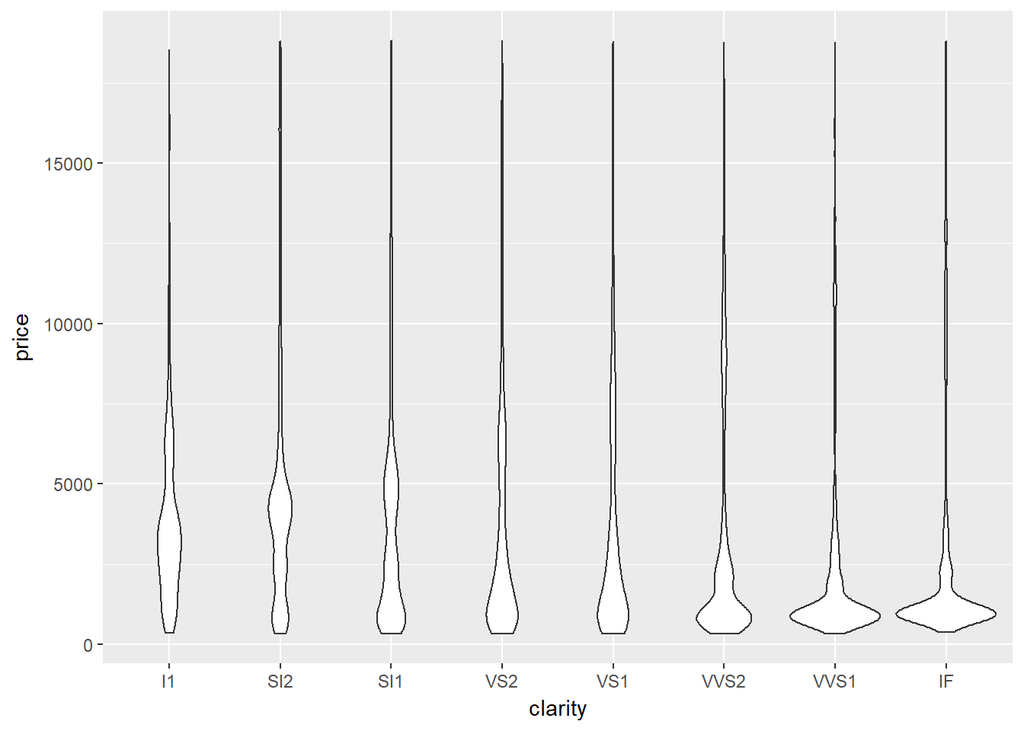

```r
ggplot(diamonds, aes(clarity, price)) +
  geom_violin()
```

Again, I am not an expert in terms of the different levels of clarity. Therefore, I am not a good judge in terms of the meaning of the plots.

*Question 4* Overlay a frequency polygon and density plot of depth. What computed variable do you need to map to y to make the two plots comparable? (You can either modify geom freqpoly() or geom density().)

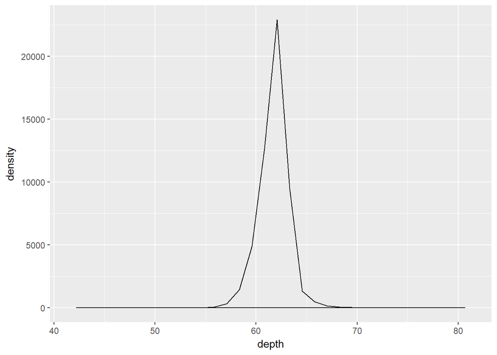

```r
ggplot(diamonds, aes(depth)) +
  geom_density(alpha = 0.1) +
  geom_freqpoly()
```

Unsure about the answer.